# Assignment 2

## Foundations of Data Mining: Assignment 2

Please complete all assignments in this notebook. You should submit this notebook, as well as a PDF version (See File > Download as).

```python
# Please fill in your names here
NAME_STUDENT_1 = "Robin Esposito"
NAME_STUDENT_2 = "Matej Grobelnik"
```

```python
%matplotlib inline
from preamble import *
plt.rcParams['savefig.dpi'] = 100 # This controls the size of your figures
# Comment out and restart notebook if you only want the last output of each cell.
#InteractiveShell.ast_node_interactivity = "all"
HTML('''<style>html, body{overflow: visible !important} .CodeMirror{min-width:105% !important;} .rise-enabled .CodeMirror, .rise-enabled .output_subarea{font-size:140%; line-height:1.2; overflow: visible;} .output_subarea pre{width:110%}</style>''') # For slides
```

## Support Vector Bananas (4 points (2+2))

We will first explore SVM kernels and hyperparameters on an artificial dataset representing multiple banana shapes.

```python
from sklearn.model_selection import *
from sklearn import svm
from sklearn.metrics import roc_auc_score
from sklearn.model_selection import GridSearchCV

bananas = oml.datasets.get_dataset(1460) # Download banana data
X, y = bananas.get_data(target=bananas.default_target_attribute);
X_train, X_test, y_train, y_test = train_test_split(X, y, random_state=0, test_size=1/4)
```

1 . Evaluate how well an SVM classifier can fit the data.

- Use a linear, polynomial and radial basis function (RBF) kernel, using their default hyperparameters. Evaluate the performance of each kernel using the test set and AUC. Which one works best?
- Visualize the results using the visualization code also used in class (under mglearn/plot_svm.py > plot_svm_kernels). Also show the AUC score and the number of support vectors. Explain intuitively how well the data is fitted, why the kernel is (not) able to fit the data, whether it is under- or overfitting, etc.

```python
auc_scores = {}
n_vectors = {}

for kernel in ('linear', 'poly', 'rbf'):

    print("Kernel: " + str(kernel))

    #fit on train data and get AUC score on test
    clf = svm.SVC(kernel=kernel)
    clf.fit(X_train, y_train)
    score = roc_auc_score(y_test, clf.decision_function(X_test))
    auc_scores[kernel] = score
    print("AUC score: {:.3f}".format(score))

    #get number of support vectors
    n_vectors[kernel] = len(clf.support_vectors_[:])
    print("Number of support vectors: {}".format(len(clf.support_vectors_[:])))

    print()
```

```
Kernel: linear
AUC score: 0.506
Number of support vectors: 3613

Kernel: poly
AUC score: 0.755
Number of support vectors: 3218

Kernel: rbf
AUC score: 0.970
Number of support vectors: 1180
```

```python
#define function to plot kernels

def plot_svm_kernel(clf, fignum, title, fig):
    # plot the line, the points, and the nearest vectors to the plane
    if fig is None:
        plt.figure(fignum, figsize=(8, 6))
        plt.suptitle(title)
    else:
        ax = fig.add_subplot(3,3,fignum)
        plt.title(title)

    plt.scatter(clf.support_vectors_[:, 0], clf.support_vectors_[:, 1], s=85, edgecolors='k', c='w', zorder=10, alpha=0.4)
    plt.scatter(X_train[:, 0], X_train[:, 1], c=y_train, zorder=10, cmap=plt.cm.bwr, alpha=0.4)

    #for i, coef in enumerate(clf.dual_coef_[0]):
        #plt.annotate("%0.2f" % (coef), (clf.support_vectors_[i, 0]+0.15,clf.support_vectors_[i, 1]), fontsize=8, zorder=11)

    plt.axis('tight')
    x_min = -3
    x_max = 3
    y_min = -3
    y_max = 3

    XX, YY = np.mgrid[x_min:x_max:200j, y_min:y_max:200j]
    Z = clf.decision_function(np.c_[XX.ravel(), YY.ravel()])

    # Put the result into a color plot
    Z = Z.reshape(XX.shape)
    if fig is None:
        plt.figure(fignum, figsize=(8, 6))
        plt.contour(XX, YY, Z, colors=['k', 'k', 'k'], linestyles=['--', '-', '--'], levels=[-.5, 0, .5])
    else:
        ax = fig.add_subplot(3,3,fignum)
        ax.contour(XX, YY, Z, colors=['k', 'k', 'k'], linestyles=['--', '-', '--'], levels=[-.5, 0, .5])

    plt.xlim(x_min, x_max)
    plt.ylim(y_min, y_max)

    plt.xticks(())
    plt.yticks(())
```

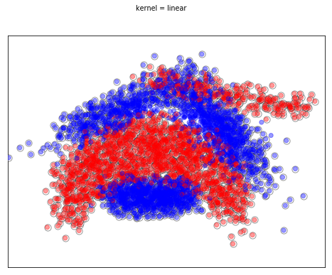

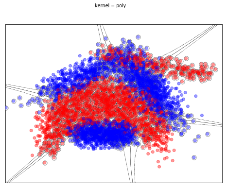

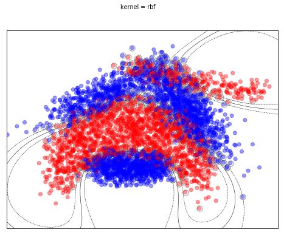

```python
# fit the models and plot
for i, kernel in enumerate(['linear', 'poly', 'rbf']):
    clf = svm.SVC(kernel=kernel)
    clf.fit(X_train, y_train)
    plot_svm_kernel(clf, i, 'kernel = %s' % kernel, None)

plt.show()
```

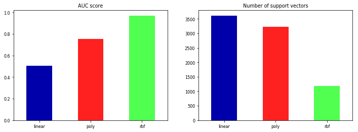

```python
#plot the scores for the three classifiers

df = pd.DataFrame(index=['linear', 'poly', 'rbf'])
df['AUC'] = auc_scores.values()
df['Support vectors'] = n_vectors.values()

fig = plt.figure(figsize=(12,4))

ax=fig.add_subplot(121)
df['AUC'].plot(kind='bar')
plt.title("AUC score")
plt.xticks(rotation='horizontal')

ax=fig.add_subplot(122)
df['Support vectors'].plot(kind='bar')
plt.title("Number of support vectors")
plt.xticks(rotation='horizontal')

plt.show()
```

Out of the three classifiers, the gaussian kernel (rbf) is the one that best fits the data. As we can see from the plots above, the linear kernel has no way to divide the data, since the elements of the two classes cannot be saparated by a straight line. The polynomial kernel performs a bit better: as we can see from the plot the curves can capture correctly some areas of the graph, but it is still far from optimal. The gaussian kernel has a much better perfomance, as it can capture the different zones of the data with greater precision.

We can conclude that the first two models are not fit to be used on this particular dataset, as for the nature of their kernels they underfit the data, while the gaussian classifier results in better precision. This can also be noted by observing the number of support vectors: the rbf kernel achieves a more defined separation of the two classes, resulting in a lower number of support vectors.

2 . Pick the RBF kernel and optimize the two most important hyperparameters (the $C$ parameter and the kernel width $\gamma$).

- First, optimize manually using 3 values for each (a very small, default, and very large value). For each of the 9 combinations, create the same RBF plot as before, report the number of support vectors, and the AUC performance. Explain the performance results. When are you over/underfitting?
- Next, optimize the hyperparameters using a grid search and 10-fold cross validation. Show a heatmap of the results snd report the optimal hyperparameter values.
  - Hint: values for C and $\gamma$ are typically in [$2^{-15}..2^{15}$] on a log scale. Use at least 10 values for each.

```
Best score: 0.973025
Best parameters: {'C': 1000, 'gamma': 'auto'}
```

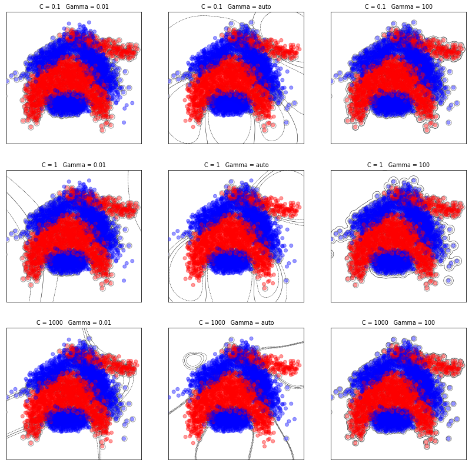

```python
#optimize c and gamma manually
best_score = 0
plot_index=1
c_range = [0.1, 1, 1000]
gamma_range = [0.01, 'auto', 100]
scores = []
vectors = []
fig = plt.figure(figsize=(14, 14))


for C in c_range:

    score_row = []
    vector_row = []
    for gamma in gamma_range:

        #fit model
        clf = svm.SVC(kernel='rbf', C=C, gamma=gamma)
        clf.fit(X_train, y_train)

        #plot
        plot_svm_kernel(clf, plot_index, 'C = {}   Gamma = {}'.format(C, gamma), fig)
        plot_index += 1

        #save all scores and best score
        score = roc_auc_score(y_test, clf.decision_function(X_test))
        score_row.append(score)
        vector_row.append(len(clf.support_vectors_[:]))
        if score > best_score:
            best_score = score
            best_parameters = {'C': C, 'gamma': gamma}

    scores.append(score_row)
    vectors.append(vector_row)

print("Best score: {:.6f}".format(best_score))
print("Best parameters: {}".format(best_parameters))
plt.show()
```

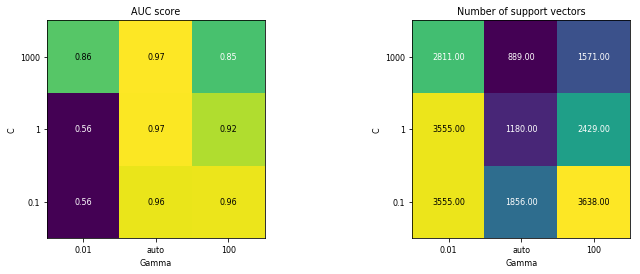

```python
#plot heatmaps
fig=plt.figure(figsize=(12,4))

fig.add_subplot(121)
mglearn.tools.heatmap(scores, xlabel='Gamma', xticklabels=gamma_range, ylabel='C', yticklabels=c_range, cmap="viridis")
plt.title("AUC score")
plt.draw()

fig.add_subplot(122)
mglearn.tools.heatmap(vectors, xlabel='Gamma', xticklabels=gamma_range, ylabel='C', yticklabels=c_range, cmap="viridis")
plt.title("Number of support vectors")
plt.draw()
```

The best perfomance overall is obtained for the default value of gamma (which is evaluated as 1/n_features) and a large value of C. We observed that in some of the plots the lines of the decision boundaries are not visible, probably due to eccessively broad or narrow Gaussians. From the middle column, we can see how higher values of the C penalty make the decision boundaries margins smaller. Decisevely high values of C can generally cause overfitting, but in this case even for C=1000 we still have a good performance. Nevertheless, we can see from both the plot and the heatmap that for a value of C=1 we already obtain an acceptable perfomance: the optimal value will probably we somewhere in between, as we will see in the next section.

As for the gamma parameter, we can see by confronting the three columns that in the first the value of gamma is too low and the data is underfitted: the zones are too broad to classify the data. On the other hand, in the third one gamma is eccessively high and it causes overfitting, as we can see from the curves that isolate the single data points. The default setting gives a better result, as the width of the Gaussian curves is fit to delimit the different zones in the data.

```python
#optimize parameters with GridSearch
param_grid = {'C': np.logspace(-15, 15, 10, base=2),
               'gamma': np.logspace(-15, 15, 10, base=2)}

grid_search = GridSearchCV(svm.SVC(kernel='rbf'), param_grid, cv=10)
grid_search.fit(X_train, y_train)

print("Best parameters: {}".format(grid_search.best_params_))
print("Best cross-validation score: {:.2f}".format(grid_search.best_score_))
```

```
Best parameters: {'C': 3250.997354430875, 'gamma': 0.31498026247371841}
Best cross-validation score: 0.90
```

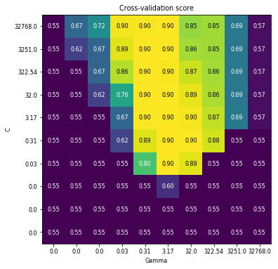

```python
#plot heatmap
fig=plt.figure(figsize=(6,6))
labels = np.round(np.logspace(-15, 15, 10, base=2),2)
grid_scores = np.array(grid_search.cv_results_['mean_test_score']).reshape(10, 10)
mglearn.tools.heatmap(grid_scores, xlabel='Gamma', xticklabels=labels,
                      ylabel='C', yticklabels=labels, cmap="viridis")
plt.title("Cross-validation score")
plt.draw()
```

The optimal parameters found using GridSearch are:

```
C ≃ 3250.99
gamma ≃ 0.315
```

## Building Kernels (4 points (0.5+0.5+1+2))

Consider the artificial dataset given below. It represents a sine wave with added noise.

1. Fit an SVM Regressor with the default RBF kernel, and plot the predictions on all data points in [0, 40].
   - Does it fit the data well? Does it extrapolate well (in the range [30,40])? Explain your findings.
   - Can you get better results by tweaking the kernel or the other SVM parameters?
2. Implement your own linear kernel. This is a function that takes 2 vectors (arrays) and returns the dot product:

   $$k(\mathbf{x}_i,\,\mathbf{x}_j) = \mathbf{x}_i \cdot \mathbf{x}_j$$
   - Build an SVM regressor using that kernel by passing your kernel function as the `kernel` hyperparameter.
   - Fit it on the sine data and plot the predictions on all data points. Interpret the results.
3. Since this data is periodic, it makes sense to implement a periodic kernel instead.
   - This is the Exponential Sine Squared kernel, with length scale $\Gamma$ and periodicity $P$: $$k(\mathbf{x}_i,\,\mathbf{x}_j) = \exp \left( -\Gamma\,\sin^2\left[\frac{\pi}{P}\,\left|\left|x_i-x_j\right|\right|\right]\right)$$
   - Implement it, using the defaults $\Gamma=1$, periodicity $P=1$, and Euclidean distance.
   - Train an SVM regressor with it, fit in on the same data and plot the result. Interpret the outcome.
   - Think about what $\Gamma$ and $P$ represent. Can you improve the fit by manually adjusting them? Explain your findings.
   - Optimize $\Gamma$ and periodicity $P$ (using `true_y` as the ground truth). Use a grid search or random search, $\Gamma \in [0,1]$, $P \in [1,100]$, try at least 5 values for each.

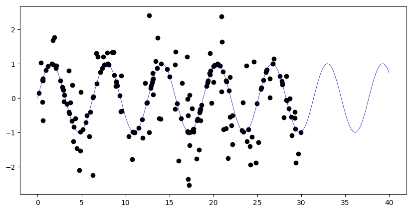

```python
# Generate sample data
rng = np.random.RandomState(0) # Random seed, for reproducibility
X = 30 * rng.rand(200, 1)
y = np.sin(X).ravel()
y[::2] += rng.normal(scale = 1.0, size = X.shape[0] // 2) # adds noise

X_plot = np.linspace(0, 40, 10000)[:, None] # A larger range to evaluate on
true_y = np.sin(X_plot) # and the 'true' target function

plt.figure(figsize=(10, 5))
plt.scatter(X, y, c='k', label='Data')
plt.plot(X_plot, true_y);
```

```python
from sklearn.svm import SVR
from sklearn.model_selection import GridSearchCV
import numpy as np
from sklearn.metrics.pairwise import euclidean_distances

indices_X_test = np.where(X_plot<=30)[0]
indices_X_extr = np.where(X_plot>30)[0]

X_test = X_plot[indices_X_test]
y_test = true_y[indices_X_test]
X_extr = X_plot[indices_X_extr]
y_extr = true_y[indices_X_extr]

param_grid = {'C': np.arange(0.1, 100, 0.5),
               'gamma': np.arange(0.1, 1.1, 0.1)}

def svr_function(kernel):
    grid_search = GridSearchCV(SVR(kernel=kernel), param_grid, cv=10, n_jobs = -1)
    grid_search.fit(X, y)

    interval1 = grid_search.score(X_test, y_test)
    print("Score in range [0,30]: {:.2f}".format(interval1))

    interval2 = grid_search.score(X_extr, y_extr)
    print("Score in range (30,40]: {:.2f}".format(interval2))

    pred = grid_search.predict(X_plot)

    print("Best parameters: {}".format(grid_search.best_params_))
    print("Best score: {:.2f}".format(grid_search.best_score_))

    plt.figure(figsize=(10, 5))
    plt.plot(X_plot, pred, 'r-')
    plt.scatter(X, y, c='k', label='Data', alpha=0.08)
    plt.plot(X_plot, true_y, 'b-', alpha=0.5)
```

```
Score on test data in range [0,30]: 0.98
Score on test data in range (30,40]: -0.18
Best parameters: {'gamma': 0.20000000000000001, 'C': 1.1000000000000001}
Best score: 0.47
```

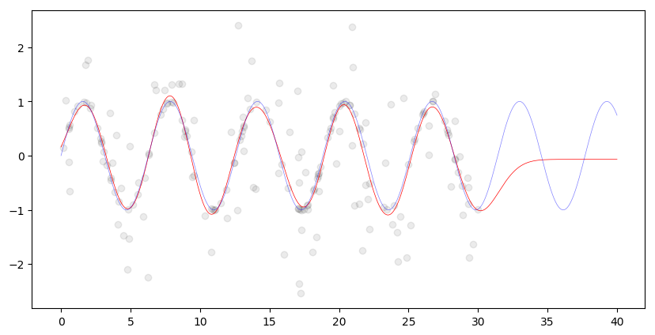

```python
svr_function('rbf')
```

Since SVR model is based on support vectors that are based on data points, it predicts 0 for all x-values bigger than 30. The model is trained on data points in range, so it will just rely on the closest support vectors resulting in a flat line. However, R^2 score in the range [0,30] was high after tweaking C and gamma parameters.

```
Score on test data in range [0,30]: -0.01
Score on test data in range (30,40]: -0.37
```

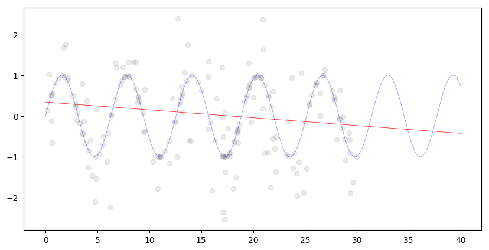

```python
def dot_product_kernel(X, y):
    return np.dot(X, y.T)

svr = SVR(kernel=dot_product_kernel)
svr.fit(X, y)
pred = svr.predict(X_plot)

interval1 = svr.score(X_test, y_test)
print("Score in range [0,30]: {:.2f}".format(interval1))

interval2 = svr.score(X_extr, y_extr)
print("Score in range (30,40]: {:.2f}".format(interval2))

plt.figure(figsize=(10, 5))
plt.plot(X_plot, pred, 'r-')
plt.scatter(X, y, c='k', label='Data', alpha=0.08)
plt.plot(X_plot, true_y, 'b-', alpha=0.5)
```

In our case the data is not linearly or polynomially separable, so changing the kernel function does not improve the extrapolation accuracy.

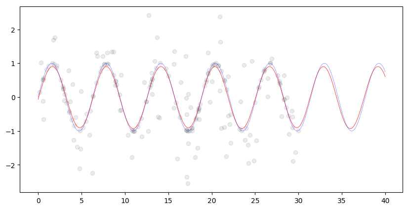

```python
def build_ess(gamma, p):
    def ess(a, b):
        return np.exp(-gamma * (np.sin(np.pi / p * euclidean_distances(a, b))) ** 2)
    return ess

param_grid = {"kernel": [build_ess(gamma, p)
                         for gamma in np.arange(0.1, 1.1, 0.1)
                         for p in np.arange(1, 100, 0.5)]}

svr = GridSearchCV(SVR(), param_grid, cv=5)
svr.fit(X, y)
pred = svr.predict(X_plot)

plt.figure(figsize=(10, 5))
plt.plot(X_plot, pred, 'r-')
plt.scatter(X, y, c='k', label='Data', alpha=0.08)
plt.plot(X_plot, true_y, 'b-', alpha=0.5)
```

*P* determines the distance between repetitions of the function and $\gamma$ determines the amplitude of the function. We manually adjusted *P* = 6.5 and $\gamma$ = 0.5 to get better results. We also did a grid search over different values of parameters.

4 . We now make the problem a bit more challenging by adding an upward trend:

- Fit the same SVM using the optimal parameters from the previous subtask and plot the results. Do they still work? Explain what you see.
- Fit a Gaussian process (GP) using the kernels given below. First use the singular ExpSineSquared kernel (the implementation provided by sklearn this time), then build a new kernel consisting of the 3 components given below. Use both to predict all points for the "rising noisy sine" data and plot the results as usual. Interpret the results.
  - For the GP, it may help to use `normalize_y=True` since the y-values are not around 0. Setting `alpha=0.1` may help with possible numerical issues, otherwise keep it at 0.
- Also plot the *uncertainty interval* around the predictions. You can ask the GP to return the standard deviation during prediction with the `return_std=True` hyperparameter. Plot a band 2 standard deviations above and below the prediction. You can use MatPlotLib's `fill_between` as shown in class.
  - You can combine the 3 models in one plot for easy comparison.
- We've provided reasonable values for the kernel hyperparameters above. Can you optimize them further to get an even better fit? Think about what the hyperparameters do and optimize the ones you think are most worth tuning.

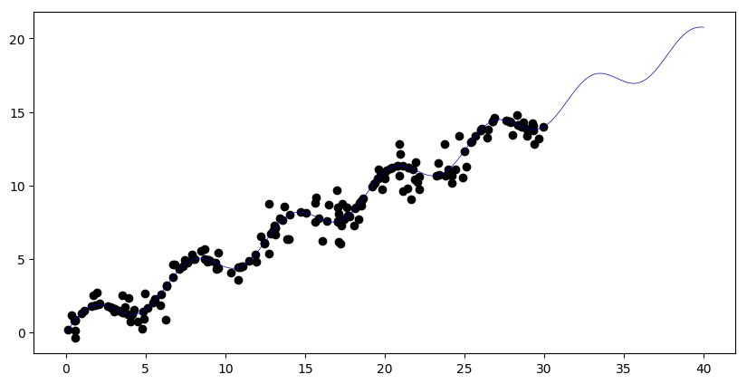

```python
# Generate sample data with added trend
rng = np.random.RandomState(0)
X = 30 * rng.rand(200, 1)
y = X.ravel()/2 + np.sin(X).ravel()
y[::2] += rng.normal(scale = 1.0, size = X.shape[0] // 2)  # add noise

X_plot = np.linspace(0, 40, 10000)[:, None]
true_y = X_plot/2 + np.sin(X_plot)

plt.figure(figsize=(10, 5))
plt.scatter(X, y, c='k', label='Data')
plt.plot(X_plot, true_y);
```

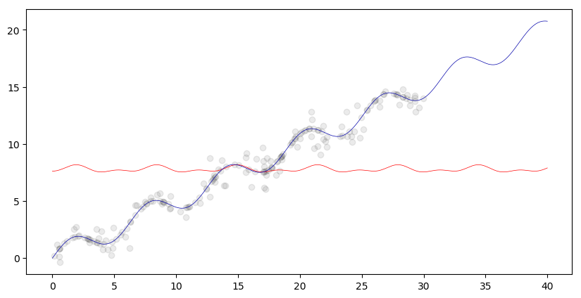

```python
svr = SVR(kernel=build_ess(0.5, 6.5))
svr.fit(X, y)
pred = svr.predict(X_plot)

plt.figure(figsize=(10, 5))
plt.plot(X_plot, pred, 'r-')
plt.scatter(X, y, c='k', label='Data', alpha=0.08)
plt.plot(X_plot, true_y);
```

Fitting the same SVM using the optimal parameters from the previous subtask does not work anymore. We can see that it does not fit the trend well and that it goes along the mean of the training data.

```python
from sklearn.gaussian_process.kernels import WhiteKernel, ExpSineSquared, RBF

# Replace `length_scale` and `periodicity` with the values found in the previous part.
kernel_simple = ExpSineSquared(length_scale=0.5, periodicity=6.5) # periodic component

k1 = 4300 * RBF(length_scale=70.0)  # long term smooth rising trend
k2 = 6 * RBF(length_scale=90.0) * ExpSineSquared(length_scale=1.3, periodicity=1.0)  # periodic component
k3 = 0.03 * RBF(length_scale=0.134) + WhiteKernel(noise_level=0.035)  # noise terms

k = k1 * k2 * k3
```

```
Score on test data in range [0,30]: 1.00
Score on test data in range (30,40]: -28.54
```

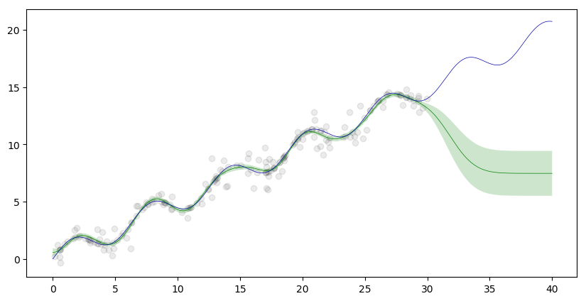

```python
from sklearn.gaussian_process import GaussianProcessRegressor

indices_X_test = np.where(X_plot<=30)[0]
indices_X_extr = np.where(X_plot>30)[0]

X_test = X_plot[indices_X_test]
y_test = true_y[indices_X_test]
X_extr = X_plot[indices_X_extr]
y_extr = true_y[indices_X_extr]

gp = GaussianProcessRegressor(kernel=kernel_simple, alpha=0.1, normalize_y=True)
gp.fit(X, y)
pred, sigma = gp.predict(X_plot, return_std=True)

interval1 = gp.score(X_test, y_test)
print("Score on test data in range [0,30]: {:.2f}".format(interval1))

interval2 = gp.score(X_extr, y_extr)
print("Score on test data in range (30,40]: {:.2f}".format(interval2))

plt.figure(figsize=(10, 5))
plt.plot(X_plot, pred, 'g-')
plt.scatter(X, y, c='k', label='Data', alpha=0.08)
plt.fill(np.concatenate([X_plot, X_plot[::-1]]),
             np.concatenate([pred - 1.9600 * sigma,
                            (pred + 1.9600 * sigma)[::-1]]),
             alpha=.2, fc='g', ec='None', label='95% confidence interval')
plt.plot(X_plot, true_y);
```

```
Score on test data in range [0,30]: 1.00
Score on test data in range (30,40]: 0.97
```

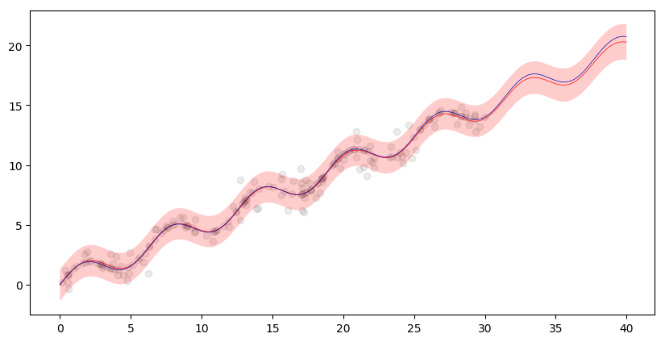

```python
gp2 = GaussianProcessRegressor(kernel=k)
gp2.fit(X, y)
pred, sigma = gp2.predict(X_plot, return_std=True)

interval1 = gp2.score(X_test, y_test)
print("Score on test data in range [0,30]: {:.2f}".format(interval1))

interval2 = gp2.score(X_extr, y_extr)
print("Score on test data in range (30,40]: {:.2f}".format(interval2))

plt.figure(figsize=(10, 5))
plt.plot(X_plot, pred, 'r-')
plt.scatter(X, y, c='k', label='Data', alpha=0.08)
plt.fill(np.concatenate([X_plot, X_plot[::-1]]),
             np.concatenate([pred - 1.9600 * sigma,
                            (pred + 1.9600 * sigma)[::-1]]),
             alpha=.2, fc='r', ec='None', label='95% confidence interval')
plt.plot(X_plot, true_y);
```

The GP using ExpSineSquared kernel with regularization and normalization fits the data perfectly on the interval [0,30]. It gives us very small confidence interval and R^2 score of 1.00. However, extrapolation performance is not good as it moves towards the mean of the data and confidence interval becomes larger.

The GP using the kernel with three components, also fits the data perfectly on the interval [0,30]. R^2 score stays the same, but the confidence interval becomes bigger. However, the difference can be spotted on the interval (30,40] where it out preforms the ExpSineSquared kernel. But since it is based on the RBF kernel which has a typical 'Gaussian shape', it will not keep an upward trend infinitely, but go downwards after a certain point. This can be already seen toward the end of the interval (30,40].

## Bayesian updates (3 points (2+1))

We consider real data about solar radiation measured by a weather balloon: https://www.openml.org/d/512. We'll use only the raw data (at least the first 1000 points) and try to learn the (very noisy) trend.

1. Train a Gaussian process on an increasing amount of samples of the training data. Use a simple RBF kernel: `RBF(10, (1e-2, 1e2))`
   - Start with 10 *random* samples and plot the predictions (both the mean and the uncertainty interval) for both training and test data, as shown in class. Also compute $R^2$ on the training data.
   - Repeat and 10 more points, retrain and redraw. Do this a couple of times and interpret/explain what you see.
2. Train the Gaussian on the full training set.
   - Plot the predictions (including the uncertainty interval) on the full dataset. Evaluate on the test set using $R^2$
   - Interpret the results. Is the kernel right? Is the GP under/overfitting?
   - Try to improve the results by tuning the kernel. Do this either manually or using a small grid/random search.

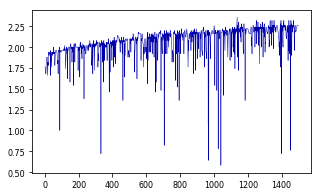

```python
from sklearn.gaussian_process import GaussianProcessRegressor
from sklearn.gaussian_process.kernels import RBF, ConstantKernel as C
from sklearn.model_selection import GridSearchCV

# Get the data
balloon_data = oml.datasets.get_dataset(512) # Download Balloon data
X, y = balloon_data.get_data(target=balloon_data.default_target_attribute);

train = X[:1000]
test = X[1000:1500]
X_train = np.array(list(range(1000)))[np.newaxis].T
y_train = X[:1000].reshape(-1, 1)
X_test = np.array(list(range(1000,1500)))[np.newaxis].T
y_test = X[1000:1500].reshape(-1, 1)
X_all = np.array(list(range(1500)))[np.newaxis].T

pd.Series(X[:1500,0]).plot();
```

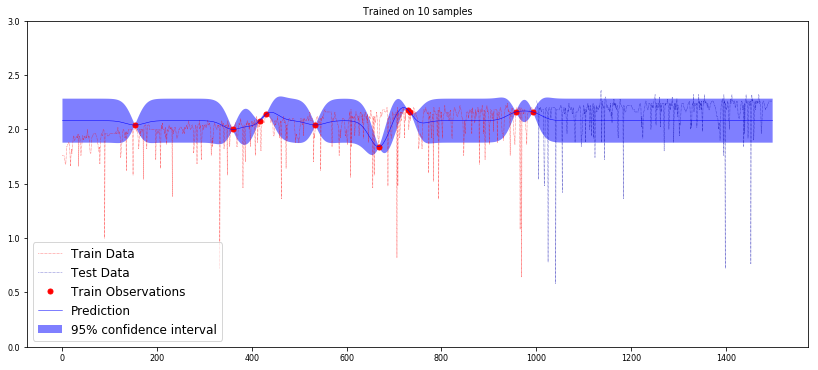

```
R^2 score on training data (10 samples): -0.18450669182154392
```

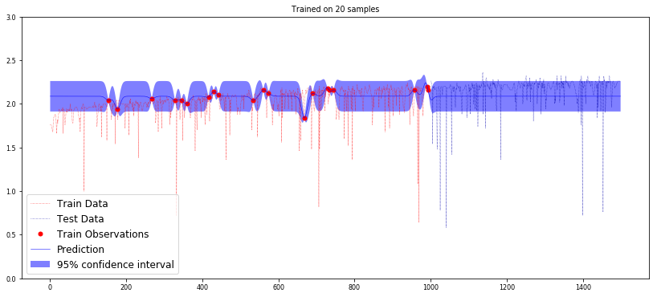

```
R^2 score on training data (20 samples): -0.1475449133695994
```

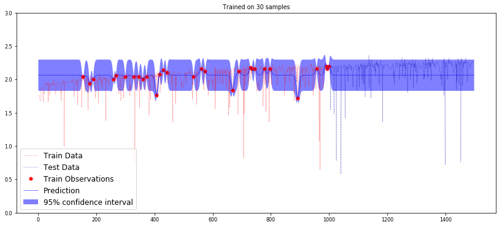

```
R^2 score on training data (30 samples): -0.1255555203141423
```

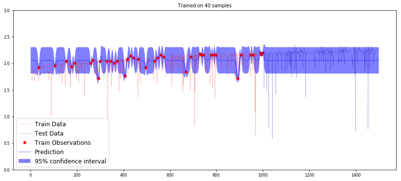

```
R^2 score on training data (40 samples): -0.09102872223737157
```

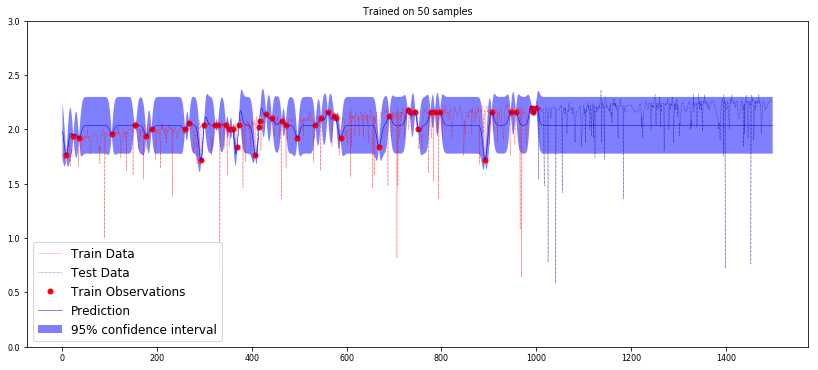

```
R^2 score on training data (50 samples): -0.02406265597119051
```

```python
indices = []

for i in range(5):
    indices.extend(np.random.choice(range(1000), size=10, replace=False))
    X_train_sample = X_train[indices]
    y_train_sample = y_train[indices]

    # Instanciate a Gaussian Process model
    kernel = 1.0 * RBF(10, (1e-2, 1e2))
    gp = GaussianProcessRegressor(kernel=kernel, n_restarts_optimizer=9, normalize_y=True, alpha=1e-06)

    # Fit to data using Maximum Likelihood Estimation of the parameters
    gp.fit(X_train_sample, y_train_sample)

    # Make the prediction on the meshed x-axis (ask for MSE as well)
    y_pred, sigma = gp.predict(X_all, return_std=True)

    # Plot the function, the prediction and the 95% confidence interval based on
    # the MSE
    fig = plt.figure(figsize=(14,6))
    plt.plot(X_train, y_train, 'r:', label=u'Train Data')
    plt.plot(X_test, y_test, ':', label=u'Test Data')
    plt.plot(X_train_sample, y_train_sample, 'r.', markersize=10, label=u'Train Observations')
    plt.plot(X_all, y_pred, 'b-', label=u'Prediction')
    plt.fill(np.concatenate([X_all, X_all[::-1]]),
         np.concatenate([y_pred.ravel() - 1.9600 * sigma,
                        (y_pred.ravel() + 1.9600 * sigma)[::-1]]),
         alpha=.5, fc='b', ec='None', label='95% confidence interval')
    plt.ylim(0, 3)
    plt.title('Trained on '+str((i+1)*10)+' samples')
    plt.legend(loc='best', prop={'size': 12})
    plt.show()

    print("R^2 score on training data ({} samples): {}\n\n".format((i+1)*10, gp.score(X_train, y_train)))
```

Generally, we can observe that the R^2 performances on training data tend to improve when increasing the number of samples. The score is heavily influenced by the quality of the randomly chosen samples: if one of the noisy observations is selected, it negatively affects the result.

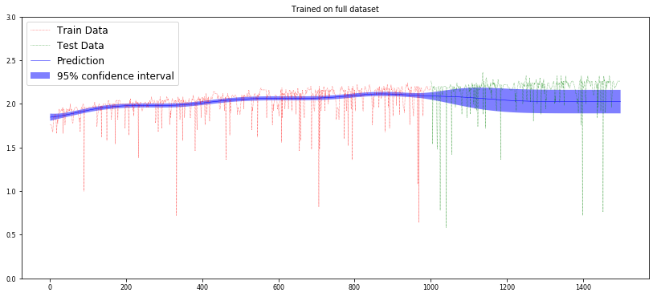

```
R^2 test score for default parameters: -0.5380864125621554
```

```python
# Training on full dataset with default kernel

# Instanciate a Gaussian Process model
kernel = 1.0 * RBF(10, (1e-2, 1e2))
gp = GaussianProcessRegressor(kernel=kernel, normalize_y=True, alpha=0.015)

# Fit to data using Maximum Likelihood Estimation of the parameters
gp.fit(X_train, y_train)

# Make the prediction on the meshed x-axis (ask for MSE as well)
y_pred, sigma = gp.predict(X_all, return_std=True)

# Plot the function, the prediction and the 95% confidence interval based on
# the MSE
fig = plt.figure(figsize=(14,6))
plt.plot(X_train, y_train, 'r:', label=u'Train Data')
plt.plot(X_test, y_test, 'g:', label=u'Test Data')
plt.plot(X_all, y_pred, 'b-', label=u'Prediction')
plt.fill(np.concatenate([X_all, X_all[::-1]]),
            np.concatenate([y_pred.ravel() - 1.9600 * sigma, (y_pred.ravel() + 1.9600 * sigma)[::-1]]),
            alpha=.5, fc='b', ec='None', label='95% confidence interval')
plt.ylim(0, 3)
plt.title('Trained on full dataset')
plt.legend(loc='best', prop={'size': 12})
plt.show()

print("R^2 test score for default parameters: {}".format(gp.score(X_test, y_test)))
```

```python
# Kernel tuning
best_score = -100
best_kernel = 1.0 * RBF(1.0)

for length_scale in [0.1, 1.0, 10]:
    for length_scale_bounds in [(1e-5, 1e5), (1e-10, 1e10), (1e-15, 1e15)]:
        kernel = 1.0 * RBF(length_scale, length_scale_bounds)
        gp = GaussianProcessRegressor(kernel=kernel, normalize_y=True, alpha=0.015)
        gp.fit(X_train, y_train)
        score = gp.score(X_test, y_test)
        print("Score for RBF({}, {}):\t{}".format(length_scale, length_scale_bounds, score))
        if score > best_score:
            best_score = score
            best_kernel = kernel

print("Best kernel: {}".format(best_kernel))
print("\nBest R^2 score: {:.2f}".format(best_score))
```

```
Score for RBF(0.1, (1e-05, 100000.0)):	-0.6394021059421475
Score for RBF(0.1, (1e-10, 10000000000.0)):	-0.6394021059421475
Score for RBF(0.1, (1e-15, 1000000000000000.0)):	-0.6394021059421475
Score for RBF(1.0, (1e-05, 100000.0)):	-0.12282063133160048
Score for RBF(1.0, (1e-10, 10000000000.0)):	-0.6394014811313575
Score for RBF(1.0, (1e-15, 1000000000000000.0)):	-0.6394014811313575
Score for RBF(10, (1e-05, 100000.0)):	-0.12282137800412385
Score for RBF(10, (1e-10, 10000000000.0)):	-0.6394014811313575
Score for RBF(10, (1e-15, 1000000000000000.0)):	-0.6394014811313575
Best kernel: 1**2 * RBF(length_scale=1)

Best R^2 score: -0.12
```

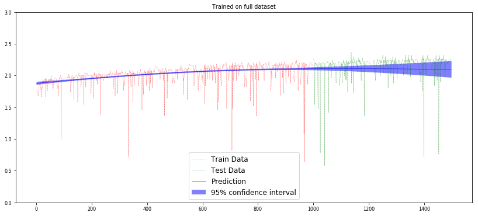

```
R^2 test score for optimized parameters: -0.12282063133160048
```

```python
# Training on full dataset with optimized kernel

# Instanciate a Gaussian Process model
gp = GaussianProcessRegressor(kernel=best_kernel, normalize_y=True, alpha=0.015)

# Fit to data using Maximum Likelihood Estimation of the parameters
gp.fit(X_train, y_train)

# Make the prediction on the meshed x-axis (ask for MSE as well)
y_pred, sigma = gp.predict(X_all, return_std=True)

# Plot the function, the prediction and the 95% confidence interval based on
# the MSE
fig = plt.figure(figsize=(14,6))
plt.plot(X_train, y_train, 'r:', label=u'Train Data')
plt.plot(X_test, y_test, 'g:', label=u'Test Data')
plt.plot(X_all, y_pred, 'b-', label=u'Prediction')
plt.fill(np.concatenate([X_all, X_all[::-1]]),
             np.concatenate([y_pred.ravel() - 1.9600 * sigma, (y_pred.ravel() + 1.9600 * sigma)[::-1]]),
             alpha=.5, fc='b', ec='None', label='95% confidence interval')
plt.ylim(0, 3)
plt.title('Trained on full dataset')
plt.legend(loc='best', prop={'size': 12})
plt.show()

print("R^2 test score for optimized parameters: {}".format(gp.score(X_test, y_test)))
```

At first we tried to use the suggested kernel with the default parameters. Beacuse of the noisy data, the GP heavily overfitted, giving very low results in the test data evaluation. For this reason, we introduced a regularization hyperparameter (alpha), and after some tests we found 0.015 to be its optimal value in this particular case. After the regularization, the GP already gave much better performances, with definitely less overfitting and a thighter confidence interval. Then, we manually tuned the kernel parameters in order to achieve an even higher R^2 score.

## A data mining challenge (4 points)

The goal here is to use everything you have learned to build the best model for a given classification task. We will use two tasks hosted on OpenML, so you will all receive the same cross-validation splits, and your model will be evaluated on the server. The goal is to reasonably select algorithms and hyperparameter settings to obtain the best model. You can also do model selection, pipeline building, and parameter optimization as you have done before. Skeleton code is provided in the OpenML tutorial. You need to optimize the AUROC score (calculated using 10-fold cross0-validation).

- Challenge 1: Detects accents in speech data.
  - The OpenML Task ID is 167132: https://www.openml.org/t/167132
  - The dataset description can be found here: https://www.openml.org/d/40910
  - Leaderboard: https://www.openml.org/t/167132#!people
- Challenge 2: Image recognition (CIFAR-10 subsample).
  - The OpenML Task ID is 167133: https://www.openml.org/t/167133
  - The dataset description can be found here: https://www.openml.org/d/40926
  - Leaderboard: https://www.openml.org/t/167133#!people
  - Note that this is a high-dimensional dataset (and not so small). Think carefully about how to run experiments in the time available.
- You are able to see the solutions of others (by clicking in the timeline or run list), so you can learn from prior experiments (what seems to work, how long does it take to train certain models, ...). Resubmission of the exact same solution is not possible.
- You can share one account (one API key) per team. In case you use two, we take the one that performs best.
- Document the different experiments that you ran in this notebook (running them can of course be done outside of the notebook). For each experiment, provide a description of how and why you chose the algorithms and parameters that you submitted. Reason about which experiments to try, don't just do an immense random search.
- Points are rewarded as follows (independently for each task):
  - 1 point for the breadth of experiments you ran (algorithms, pipelines, hyperparameter settings)
  - 1 point for reasoning/insight and interpretation of the results
  - 1 (bonus) point for every team who has uploaded the best solution thus far **on AUC** (who reaches the top of the leaderboard at any moment during the assignment)
    - Exception: simply repeating top models with nearly identical hyperparameters. This will be checked on the timeline.
    - Note: On the leaderboard page, the 'frontier' line is drawn, and your top ranking is also shown in the leaderboard.

Note: Report the AUC scores of your best models in your report as well. In case of issues with OpenML we will use the experiments and scores mentioned your report.

### Challenge 1

The goal of this challenge is a supervised classification task. The dataset contains real world data from recorded English language.

First, we tried different classifiers with scaling and without on a grid search to get a general idea. We did search over neighbors.KNeighborsClassifier(), ensemble.RandomForestClassifier(), ensemble.GradientBoostingClassifier(), linear_model.LogisticRegression(), svm.SVC() and gaussian_process.GaussianProcessClassifier().

We compared our conclusions with the perfomances already achieved on the OpenML leaderboard and we decided to focus on kNN classifier. We also used dimensionality reduction technique PCA. Next, we searced for optimal number of k neighbors for roc_auc and accuracy score.

```python
from sklearn import pipeline, ensemble, preprocessing, decomposition, neighbors
from sklearn.metrics import roc_auc_score
from sklearn.model_selection import GridSearchCV
from sklearn.decomposition import PCA
from sklearn.feature_selection import SelectKBest, chi2

task = oml.tasks.get_task(167132)

data1 = oml.datasets.get_dataset(40910)
X, y = data1.get_data(target=data1.default_target_attribute);

X_train, X_test, y_train, y_test = train_test_split(X, y)
```

```python
scoring='roc_auc'

cvk_scores = []
auc_scores = []
j = range(1,35)

for k in j:
    pipe = pipeline.Pipeline(steps=[
            ('Scaler', preprocessing.StandardScaler()),
            ('reduce_dim', PCA()),
            ('Classifier', neighbors.KNeighborsClassifier(n_neighbors=k, n_jobs=-1))
           ])
    scores_auc = cross_val_score(pipe, X, y, cv=10, scoring='roc_auc', n_jobs=-1)
    scores = cross_val_score(pipe, X, y, cv=10, scoring='accuracy', n_jobs=-1)
    cvk_scores.append(scores.mean())
    auc_scores.append(scores_auc.mean())

MSEk = [x for x in cvk_scores]
MSE_auc = [x for x in auc_scores]

optimal_k = j[MSEk.index(min(MSEk))]
optimal_auc_k = j[MSE_auc.index(min(MSE_auc))]
print("The optimal number of k neighbors is ", optimal_k)
print("The optimal number of k neighbors is ", optimal_auc_k)
```

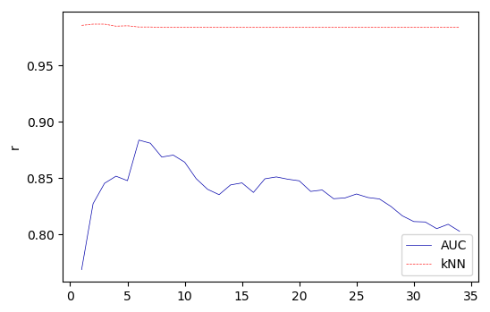

```
The optimal number of k neighbors is  3
The optimal number of k neighbors is  6
```

```
0.87024755128065989
```

```python
plt.plot(j, MSE_auc, label = 'AUC')
plt.plot(j, MSEk, label = 'kNN')
plt.legend()
plt.ylabel('r')
plt.show()

optimal_k = j[MSEk.index(max(MSEk))]
optimal_auc_k = j[MSE_auc.index(max(MSE_auc))]
print("The optimal number of k neighbors is ", optimal_k)
print("The optimal number of k neighbors is ", optimal_auc_k)
MSE_auc[8]
```

```python
pipe = pipeline.Pipeline(steps=[
        ('Scaler', preprocessing.StandardScaler()),
        ('reduce_dim', PCA()),
        ('Classifier', neighbors.KNeighborsClassifier(n_neighbors=k, n_jobs=-1))
       ])
scores_auc = cross_val_score(pipe, X_train, y_train, cv=10, scoring='roc_auc', n_jobs=-1)
scores = cross_val_score(pipe, X_train, y_train, cv=10, scoring='accuracy', n_jobs=-1)
print("Mean cross-validation score: ", scores_auc.mean())
print("Mean cross-validation score: ", scores.mean())
```

```python
pipe = pipeline.Pipeline(steps=[
            ('Scaler', imblearn.over_sampling.adasyn.ADASYN()),
            ('reduce_dim', PCA()),
            ('Classifier', neighbors.KNeighborsClassifier(n_neighbors=6, n_jobs=-1))
           ])

flow = oml.flows.sklearn_to_flow(pipe)
run = oml.runs.run_flow_on_task(task, flow)
myrun = run.publish()
print("Uploaded to http://www.openml.org/r/" + str(myrun.run_id))
```

### Challenge 2

The goal of this challenge is a supervised classification task. The dataset is a subset of CIFAR10: it consists of 20,000 labeled instances of 32x32 color images, classified into 10 different classes. Therefore we are facing an image classification problem: this implies high-dimensional data.

At first we considered using SVM, which has good performances on high-dimensional data, but the size of the dataset would have prevented us from achieving an acceptable efficiency. On the other hand, we excluded Gaussian Processes because they do not perform well with high-dimensional data. Because of the size of the dataset that we are using to train the model, we excluded high bias/low variance classifiers (such as Naive Bayes) to focus on low bias/high variance ones (with the exception of Gradient Boosting, which can be very effective on big datasets, if opportunely tuned).

We compared our conclusions with the perfomances already achieved on the OpenML leaderboard and we decided to focus on three particular classifiers: K-Neighbors, Random Forest and Gradient Boosting. The experiments and the hyperparameters tuning were done outside of this notebook for efficiency reasons, here we report the results.

```python
from sklearn import pipeline, ensemble, preprocessing, decomposition, neighbors

task = oml.tasks.get_task(167133)
```

We experimented with different types of scalers and we found that the K-Neighbors Classifier gave the best performances when paired with a StandardScaler. Then we tuned the number of neighbors of the classifier: the optimal value resulted to be 100 neigbhors. When run on OML, this model achieved an AUC score of 0,7959.

```python
#KNeighbors

pipe = pipeline.Pipeline(steps=[
            ('Scaler', preprocessing.StandardScaler()),
            ('Classifier', neighbors.KNeighborsClassifier(n_neighbors=100))
           ])

flow = oml.flows.sklearn_to_flow(pipe)
run = oml.runs.run_flow_on_task(task, flow)
myrun = run.publish()
print("Uploaded to http://www.openml.org/r/" + str(myrun.run_id))
```

```
Uploaded to http://www.openml.org/r/8885393
```

When using the Random Forest Classifier, we found that the best method to preprocess the data was to use MinMaxScaler. We also tried to recude the dimensionality of the dataset using PCA, but the results did not improve, showing that this model works well with high-dimensional data. Then, we tuned the 'max_features' and 'n_estimators' hyperparameters: the optimal values turned out to be 60 and 200 respectively. The AUC score obtained for this model was 0,8485.

```python
#RandomForest

pipe = pipeline.Pipeline(steps=[
            ('Scaler', preprocessing.MinMaxScaler()),
            ('Classifier', ensemble.RandomForestClassifier(max_features=60, n_estimators=200))
           ])

flow = oml.flows.sklearn_to_flow(pipe)
run = oml.runs.run_flow_on_task(task, flow)
myrun = run.publish()
print("Uploaded to http://www.openml.org/r/" + str(myrun.run_id))
```

```
Uploaded to http://www.openml.org/r/8885412
```

The Gradient Boosting classifier gave the best results when used in a pipeline together with a Robust Scaler. From our experiments, it resulted that the optimal value fo the 'max_depth' parameter was quite high (7), but for efficiency reasons we tuned it down to 5. We also set the 'max_feauters' parameter to 40, to achieve faster performances. The AUC score achieved with this classifier was 0,8706.

```python
#GradientBoosting

pipe = pipeline.Pipeline(steps=[
            ('Scaler', preprocessing.RobustScaler()),
            ('Classifier', ensemble.GradientBoostingClassifier(learning_rate=0.1, max_depth=5, max_features=40, n_estimators=100))
           ])

flow = oml.flows.sklearn_to_flow(pipe)
run = oml.runs.run_flow_on_task(task, flow)
myrun = run.publish()
print("Uploaded to http://www.openml.org/r/" + str(myrun.run_id))
```

```
Uploaded to http://www.openml.org/r/8886484
```

**Conclusions**

Out of three classifiers we selected, the one with the best performance resulted to be Gradient Boosting, shortly followed by Random Forest. The third classifier, K-Neighbors, gave sufficiently good performances when paired with a Standard Scaler, but still worse than the other two. This outcome confirms our original hypothesis: generally, variance-reduction techniques are more fit for classification tasks on large datasets with high-dimensional data but, if carefully tuned, Gradient Boosting (which is bias-reduction) gives equally good or even better results. The main problem in tuning the Gradeint Boosting classifier was the running time: contrarily to Random Forest, this kind of classifier can not parallelize and therefore for a high number of iterations the time becomes impratically long. We found a solution to this by limiting the number of features to consider when choosing the best slipt, using the max_features parameter. We concluded that, if opportunely tuned, the Gradient Boosting classifier can achieve a good tradeoof between AUC score and fastness and is therefore the best possible solution for this task.